# What’s in Your Food?

January 22, 2015

## Overview of "What's in Your Food"

### App is a tool for nutrition insight discovery and visualization

Ever wonder how much dietary fiber is in your burrito?

Ever wonder what you should eat to maximize your protein intake while minimizing your fat intake?

**You can use this app to answer those questions and more.**

[figure not shown]

Screenshot of "What's in Your Food?" (Click screenshot to visit)

## How does it add value?

### "What's in Your Food?" provides insights through interactive visualization

[interactive chart not shown]

#### Detailed nutrition facts

- Data are from the [USDA's Nutrition Database](http://ndb.nal.usda.gov/ndb/) which, while not visually friendly, is the go-to source for accurate and detailed nutrition data

#### Easy to use

- Users can navigate foods with an interactive graph or table
- Filters and search help users find subsets of food easily and creatively

#### Visual

- Users can plot foods by nutrient values and food groups and quickly visualize their findings
- Dynamic tooltips make weaving through the data much easier

## What data are in the app?

### Users can analyze 8617 foods based on 46 nutritional content indicators

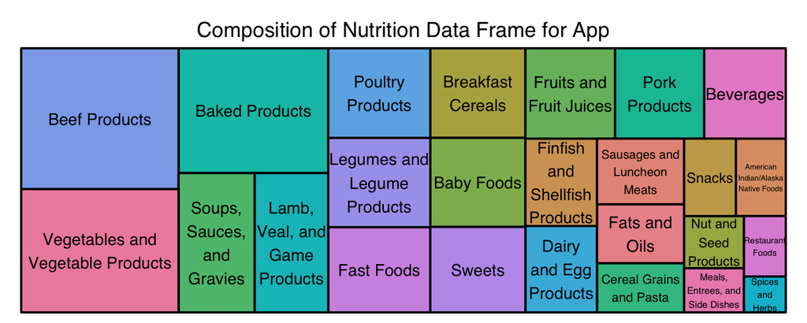

```r
food_count <- as.data.frame(table(df$FoodGroup))
treemap(food_count, "Var1", "Freq", fontface.labels = "plain",
        title = "Composition of Nutrition Data Frame for App")
```

## Further applications and development

### This app can be further improved upon for added functionality

Who can use this?

- Dieticians and nutritionists
- Chefs
- The USDA and NDA (and other government organizations)
- Researchers and food studies students
- Anyone trying to maximize or minimize intake of a specific nutrient
- The curious and bored!

Future features

- Food recommendation function which takes an input of a set of objectives and provides a list of foods that meet those objectives
- **Example:** *Input objective to minimize sodium while maximizing iron intake, output is a list of foods with the highest iron to sodium ratio*
- Ability to click on an ingredient on the chart and display the ingredient makeup in a separate chart beside it